# R语言统计基础

## 随机变量

```r
n <- sample(1:5,size = 100,replace = T,prob = c(0.1,0.1,0.3,0.3,0.2))
table(n)
```

```
n
 1  2  3  4  5
12  7 30 29 22
```

```r
table(n)/100
```

```
n
   1    2    3    4    5
0.12 0.07 0.30 0.29 0.22
```

## 沪深300收益率数据

```r
HSRet300 <- read.csv("return300.csv",header = T)
head(HSRet300)
```

|  | date | return | sig |
| --- | --- | --- | --- |
| 1 | 2014/1/2 | -0.345 | 0 |
| 2 | 2014/1/3 | -1.344 | 0 |
| 3 | 2014/1/6 | -2.276 | 0 |
| 4 | 2014/1/7 | -0.028 | 0 |
| 5 | 2014/1/8 | 0.175 | 1 |
| 6 | 2014/1/9 | -0.878 | 0 |

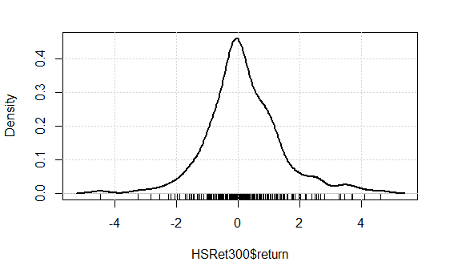

```r
library(car)
densityPlot(HSRet300$return)
```

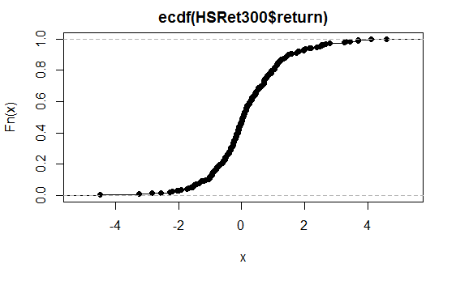

```r
plot(ecdf(HSRet300$return))
```

## 二项分布随机数

```r
rbinom(20,100,0.5)
```

```
 [1] 52 48 55 52 58 40 54 54 46 53 54 55 48 45 46 49 46 52 49 43
```

```r
rbinom(3,10,0.5)
```

```
[1] 6 2 4
```

```r
dbinom(20,100,0.5)
```

```
[1] 4.2e-10
```

```r
dd <- dbinom(0:20,100,0.5)
dd
```

```
 [1] 7.9e-31 7.9e-29 3.9e-27 1.3e-25 3.1e-24 5.9e-23 9.4e-22
 [8] 1.3e-20 1.5e-19 1.5e-18 1.4e-17 1.1e-16 8.3e-16 5.6e-15
[15] 3.5e-14 2.0e-13 1.1e-12 5.2e-12 2.4e-11 1.0e-10 4.2e-10
```

```r
sum(dd)
```

```
[1] 5.6e-10
```

```r
pbinom(20,100,0.5)
```

```
[1] 5.6e-10
```

## 正态分布

```r
Norm<-rnorm(5)
Norm
```

```
[1] -1.21  0.11 -1.03  0.69  0.73
```

```r
dnorm(Norm)
```

```
[1] 0.19 0.40 0.23 0.31 0.31
```

```r
pnorm(Norm)
```

```
[1] 0.11 0.55 0.15 0.75 0.77
```

```r
HSRet300<-read.csv("return300.csv",header=T)
m=mean(HSRet300$return)
variance=var(HSRet300$return)
m
```

```
[1] 0.18
```

```r
variance
```

```
[1] 1.5
```

```r
qnorm(p=0.05,mean=m,sd=sqrt(variance))
```

```
[1] -1.8
```

## 因子

```r
y <- c("A","B","A","B","B","B","A","B","B","A")
y
```

```
 [1] "A" "B" "A" "B" "B" "B" "A" "B" "B" "A"
```

```r
(f <- factor(y))
```

```
 [1] A B A B B B A B B A
Levels: A B
```

```r
levels(f)
```

```
[1] "A" "B"
```

# 探索性数据分析

也成为描述性统计分析，是通过分析数据集以决定选择哪种方法适合统计推断的过程，例如是否服从正态分布等。

## 探索性数据分析的主要工具

主要的图形表示工具如下：

- 条图（BarPlot）
- 直方图（Hist）
- 箱型图（BoxPlot）
- 正态概率图（Qqnorm）  
  例如：随机抽样24人的数学和统计课程成绩，存入文本文件mathstat.txt文件。

```r
MS=read.table("mathstat.txt",header = T)
head(MS)
```

|  | math | stat |
| --- | --- | --- |
| 1 | 81 | 72 |
| 2 | 91 | 96 |
| 3 | 74 | 68 |
| 4 | 70 | 82 |
| 5 | 90 | 90 |
| 6 | 73 | 78 |

```r
dim(MS)
```

```
[1] 24  2
```

应用茎叶图对数学和统计成绩做初步认识：

```r
stem(MS$math)
```

```
  The decimal point is 1 digit(s) to the right of the |

  5 | 4
  6 | 00368
  7 | 003478
  8 | 01134558
  9 | 0135
```

```r
stem(MS$stat)
```

```
  The decimal point is 1 digit(s) to the right of the |

  5 | 68
  6 | 68
  7 | 1235688
  8 | 22246679
  9 | 04668
```

将常用图形函数整合到函数EDA中：

```r
EDA <- function (x)
  {
    par(mfrow=c(2,2))              #four
    hist(x)                        #hist
    dotchart(x)                    #dotchart
    boxplot(x,horizontal=T)        #boxplot
    qqnorm(x);qqline(x)            #qqnorm
    par(mfrow=c(1,1))              #restore single
  }
```

用上述函数分析数学和统计成绩：

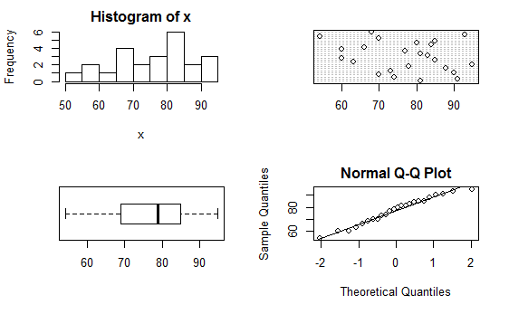

```r
EDA(MS$math)
```

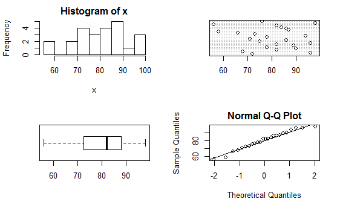

```r
EDA(MS$stat)
```

## 单变量数据分析

分类频数表（Table）：例如，关于是否抽烟的调查

```r
x <- c("yes","no","no","yes","yes","yes","no","no","yes")
table(x)
```

```
x
 no yes
  4   5
```

```r
x
```

```
[1] "yes" "no"  "no"  "yes" "yes" "yes" "no"  "no"  "yes"
```

条图（barplot）：高度可以是频数或频率，应该先对数据分组。例如，对饮酒类型的调查，按红酒（1）、白酒（2）、黄酒（3）、啤酒（4）分成四类，调查数据如下：

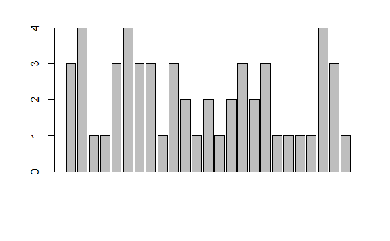

```r
drink <- c(3,4,1,1,3,4,3,3,1,3,2,1,2,1,2,3,2,3,1,1,1,1,4,3,1)
barplot(drink)
```

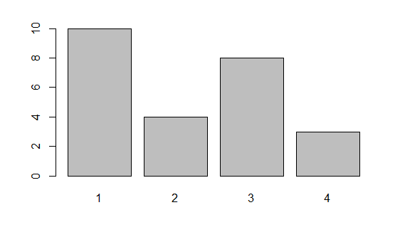

```r
barplot(table(drink))
```

第一个图其实没有意义。 饼图（Pie）

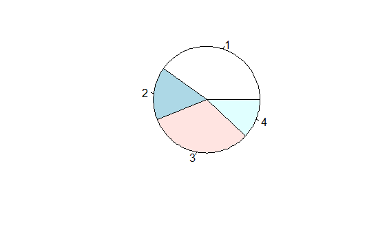

```r
pie(table(drink))
```

将默认分类改成文字

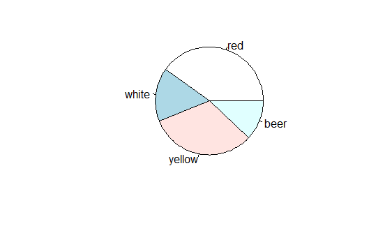

```r
drink.count <- table(drink)
names(drink.count) <- c("red","white","yellow","beer")
pie(drink.count)
```

集中趋势和离散程度：均值、方差、分位数等。

```r
salary=c(2000,2100,2200,2300,2350,2450,2500 ,2700,2900,2850,3500,3800,2600,
         3000,3300,3200,4000,3100,4200)
mean(salary)
```

```
[1] 2897
```

```r
median(salary)
```

```
[1] 2850
```

```r
var(salary)
```

```
[1] 414854
```

```r
sd(salary)
```

```
[1] 644
```

```r
fivenum(salary)
```

```
[1] 2000 2400 2850 3250 4200
```

```r
summary(salary)
```

```
   Min. 1st Qu.  Median    Mean 3rd Qu.    Max.
   2000    2400    2850    2900    3250    4200
```

## 双变量数据分析

二维表：例如，调查关于学生是否抽烟与每天学习时间的问题。

```r
smoke=c("Y","N","N","Y","N","Y","Y","Y","N","Y")
study=c("<5h","5-10h","5-10h",">10h",">10h","<5h","5-10h","<5h",">10h","5-10h")
table(smoke,study)
```

```
     study
smoke <5h >10h 5-10h
    N   0    2     2
    Y   3    1     2
```

计算比例：

```r
tab=table(smoke,study)
prop.table(tab,1)
```

```
     study
smoke  <5h >10h 5-10h
    N 0.00 0.50  0.50
    Y 0.50 0.17  0.33
```

```r
prop.table(tab,2)
```

```
     study
smoke  <5h >10h 5-10h
    N 0.00 0.67  0.50
    Y 1.00 0.33  0.50
```

```r
prop.table(tab)
```

```
     study
smoke <5h >10h 5-10h
    N 0.0  0.2   0.2
    Y 0.3  0.1   0.2
```

复式条图：

```r
par(mfrow=c(1,3))
barplot(table(smoke,study))
barplot(table(study,smoke))
```

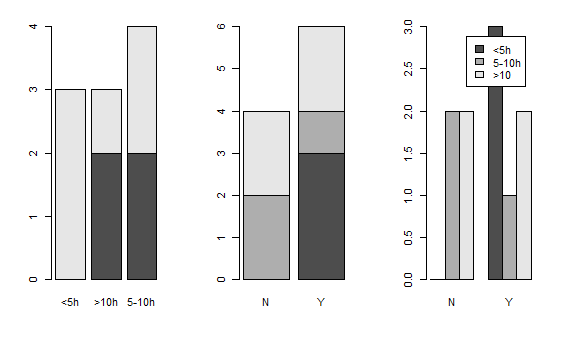

```r
barplot(table(study,smoke),beside=T,legend.text=c("<5h","5-10h",">10"))
par(mfrow=c(1,1))
```

散点图：例如，财政收入和税收数据按年统计的结果

```r
revenue <- read.table("revenue.txt",header = T)
revenue
```

| t | y | x |
| --- | --- | --- |
| 1990 | 2937 | 2822 |
| 1991 | 3149 | 2990 |
| 1992 | 3483 | 3297 |
| 1993 | 4349 | 4255 |
| 1994 | 5218 | 5127 |
| 1995 | 6242 | 6038 |
| 1996 | 7408 | 6910 |
| 1997 | 8651 | 8234 |
| 1998 | 9876 | 9263 |
| 1999 | 11444 | 10683 |

[output cut: 2 more lines]

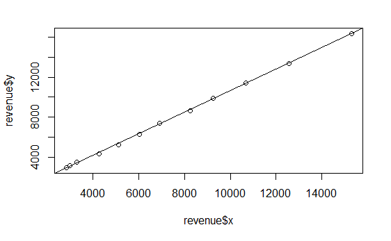

```r
plot(revenue$x,revenue$y)
abline(lm(revenue$y~revenue$x))
```

相关系数：

```r
cor(revenue$x,revenue$y)
```

```
[1] 1
```

```r
cor(revenue$y,revenue$x)
```

```
[1] 1
```

## 多变量数据分析

多维列联表：以MASS包中的Cars93数据为例进行分析

```r
library(MASS)
data(Cars93)
dim(Cars93)
```

```
[1] 93 27
```

```r
attach(Cars93)
names(Cars93)
```

```
 [1] "Manufacturer"       "Model"              "Type"
 [4] "Min.Price"          "Price"              "Max.Price"
 [7] "MPG.city"           "MPG.highway"        "AirBags"
[10] "DriveTrain"         "Cylinders"          "EngineSize"
[13] "Horsepower"         "RPM"                "Rev.per.mile"
[16] "Man.trans.avail"    "Fuel.tank.capacity" "Passengers"
[19] "Length"             "Wheelbase"          "Width"
[22] "Turn.circle"        "Rear.seat.room"     "Luggage.room"
[25] "Weight"             "Origin"             "Make"
```

一共27个变量，93行数据。 把价格Price按照（0,12）、（12,20），（20，最大值）分成经济型、普通型、奢侈型；把MPGhighway分成费油型、普通型、省油型。用cut函数分组：

```r
price=cut(Price,c(0,12,20,max(Price)))
table(price)
```

```
price
   (0,12]   (12,20] (20,61.9]
       22        40        31
```

```r
levels(price)=c("cheap","okay","expensive")
table(price)
```

```
price
    cheap      okay expensive
       22        40        31
```

```r
mpg=cut(MPG.highway,c(0,20,30,max(MPG.highway)))
table(mpg)
```

```
mpg
 (0,20] (20,30] (30,50]
      2      62      29
```

```r
levels(mpg)=c("gas guzzler","oky","miser")
table(mpg)
```

```
mpg
gas guzzler         oky       miser
          2          62          29
```

作price和type的二维表以及price、type和mpg的三位表：

```r
table(Type)
```

```
Type
Compact   Large Midsize   Small  Sporty     Van
     16      11      22      21      14       9
```

```r
table(price,Type)
```

```
           Type
price       Compact Large Midsize Small Sporty Van
  cheap           3     0       0    18      1   0
  okay            9     3       8     3      9   8
  expensive       4     8      14     0      4   1
```

```r
table(price,mpg)
```

```
           mpg
price       gas guzzler oky miser
  cheap               0   5    17
  okay                2  26    12
  expensive           0  31     0
```

```r
table(price,Type,mpg)
```

```
, , mpg = gas guzzler

           Type
price       Compact Large Midsize Small Sporty Van
  cheap           0     0       0     0      0   0
  okay            0     0       0     0      0   2
  expensive       0     0       0     0      0   0

, , mpg = oky

           Type
price       Compact Large Midsize Small Sporty Van
  cheap           1     0       0     4      0   0
  okay            5     3       6     0      6   6
  expensive       4     8      14     0      4   1

, , mpg = miser

           Type
price       Compact Large Midsize Small Sporty Van
  cheap           2     0       0    14      1   0
  okay            4     0       2     3      3   0
  expensive       0     0       0     0      0   0
```

复式条形图：

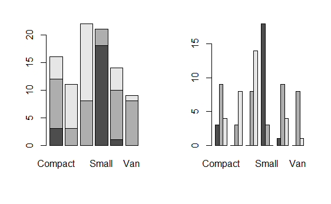

```r
par(mfrow=c(1,2))
barplot(table(price,Type))
barplot(table(price,Type),beside=T)
```

```r
barplot(table(Type,price))
barplot(table(Type,price),beside=T)
```

[figure not shown]

```r
par(mfrow=c(1,1))
```

矩阵式散点图：考察三个或三个以上变量间关系时，绘制矩阵散点图可以快速发现多个变量间的主要相关性,以数据集iris（鸢尾花）为例。函数pairs（）

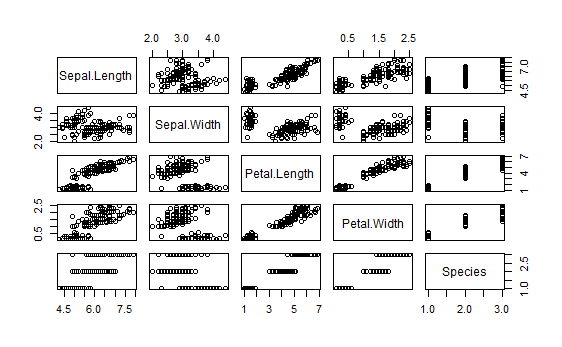

```r
pairs(iris)
```